# Test+a+Perceptual+Phenomenon+zh

### 统计学：检验心理学现象

在下方单元格中回答问题并执行相关代码，你可以 参考项目指导 并在正式提交前查看 [项目要求](https://review.udacity.com/#!/rubrics/305/view)。提交时请将 Jupyter notebook 导出成 HTML 或者 PDF 进行提交（File -> Download As）。

背景信息

在一个Stroop （斯特鲁普）任务中，参与者得到了一列文字，每个文字都用一种油墨颜色展示。参与者的任务是将文字的打印颜色大声说出来。这项任务有两个条件：一致文字条件，和不一致文字条件。在一致文字条件中，显示的文字是与它们的打印颜色匹配的颜色词，如“红色”、“蓝色”。在不一致文字条件中，显示的文字是与它们的打印颜色不匹配的颜色词，如“紫色”、“橙色”。在每个情况中，我们将计量说出同等大小的列表中的墨色名称的时间。每位参与者必须全部完成并记录每种条件下使用的时间。

调查问题

作为一般说明，请确保记录你在创建项目时使用或参考的任何资源。作为项目提交的一部分，你将需要报告信息来源。

(1) 我们的自变量是什么？因变量是什么？

--答案写这里--

自变量：文字和油墨颜色的一致性；

因变量：说出同等大小的列表中的墨色名称的时间。

(2) 此任务的适当假设集是什么？你需要以文字和数学符号方式对假设集中的零假设和对立假设加以说明，并对数学符号进行定义。你想执行什么类型的统计检验？为你的选择提供正当理由（比如，为何该实验满足你所选统计检验的前置条件）。

--答案写这里--

此效应展示了人们对事物的认知过程已是一个自动化的历程。当有一个新的刺激出现时，如果它的特征和原先的刺激相似或符合一致，便会加速人们的认知；反之，若新的刺激特征与原先的刺激不相同，则会干扰人们的认知，使人们的所需的反应时间变长。

μc：代表文字条件一致的情况下,识别时间的总体均值；

μi：代表文字条件不一致的情况下,识别时间的总体均值；

$H_{0}$零假设: 在文字条件一致和不一致相等的情况下, 它们识别时间的总体均值相同；

$H_{1}$对立假设: 针对一致文字条件说出对应墨色的平均时间要比不一致文字条件的列表说出对应墨色的平均时间少;

$H_{0}$: μc = μi

执行统计检验的类型：

使用Paired T-Test，T-Test的P值为two-tail。a level=0.05。

理由如下：

1.由于此实验中并不知道总体参数且样本量<30,根据T检验和Z检验的概念可知，选择T检验；

2.假设验证是否两个总参相等或不相等，所以选择双尾检测；

3.由于是同一测试者参与的不同测试，所以为相依样本；

现在轮到你自行尝试 Stroop 任务了。前往此链接，其中包含一个基于 Java 的小程序，专门用于执行 Stroop 任务。记录你收到的任务时间（你无需将时间提交到网站）。现在下载此数据集，其中包含一些任务参与者的结果。数据集的每行包含一名参与者的表现，第一个数字代表他们的一致任务结果，第二个数字代表不一致任务结果。

(3) 报告关于此数据集的一些描述性统计。包含至少一个集中趋势测量和至少一个变异测量。

```python
# 在这里执行你的分析
```

```python
import pandas as pd
import numpy as np
%matplotlib inline
import seaborn as sns
from scipy.stats import t
import matplotlib.pyplot as plt
import math
df= pd.read_csv('stroopdata.csv')
df
```

|  | Congruent | Incongruent |
| --- | --- | --- |
| 0 | 12.079 | 19.278 |
| 1 | 16.791 | 18.741 |
| 2 | 9.564 | 21.214 |
| 3 | 8.630 | 15.687 |
| 4 | 14.669 | 22.803 |
| 5 | 12.238 | 20.878 |
| 6 | 14.692 | 24.572 |
| 7 | 8.987 | 17.394 |
| 8 | 9.401 | 20.762 |
| 9 | 14.480 | 26.282 |
| 10 | 22.328 | 24.524 |
| 11 | 15.298 | 18.644 |
| 12 | 15.073 | 17.510 |
| 13 | 16.929 | 20.330 |
| 14 | 18.200 | 35.255 |
| 15 | 12.130 | 22.158 |
| 16 | 18.495 | 25.139 |
| 17 | 10.639 | 20.429 |
| 18 | 11.344 | 17.425 |
| 19 | 12.369 | 34.288 |
| 20 | 12.944 | 23.894 |
| 21 | 14.233 | 17.960 |
| 22 | 19.710 | 22.058 |
| 23 | 16.004 | 21.157 |

```python
df.info()
```

```
<class 'pandas.core.frame.DataFrame'>
RangeIndex: 24 entries, 0 to 23
Data columns (total 2 columns):
Congruent      24 non-null float64
Incongruent    24 non-null float64
dtypes: float64(2)
memory usage: 464.0 bytes
```

```python
sum(df.duplicated())
```

```
0
```

```python
df.describe()
```

|  | Congruent | Incongruent |
| --- | --- | --- |
| count | 24.000000 | 24.000000 |
| mean | 14.051125 | 22.015917 |
| std | 3.559358 | 4.797057 |
| min | 8.630000 | 15.687000 |
| 25% | 11.895250 | 18.716750 |
| 50% | 14.356500 | 21.017500 |
| 75% | 16.200750 | 24.051500 |
| max | 22.328000 | 35.255000 |

```python
df.median()
```

```
Congruent      14.3565
Incongruent    21.0175
dtype: float64
```

```python
df.quantile(0.75)-df.quantile(0.25)
```

```
Congruent      4.30550
Incongruent    5.33475
dtype: float64
```

```python
df.max()-df.min()
```

```
Congruent      13.698
Incongruent    19.568
dtype: float64
```

**集中趋势测量**

1. 均值：
   - 一致文字条件下：$\overline{x}_{con} = 14.051125$
   - 不一致文字条件下：$\overline{x}_{incon} = 22.015917$
2. 中位数：
   - 一致文字条件下：$median_{con} = 14.3565$
   - 不一致文字条件下：$median_{incon} = 21.0175$

**变异测量**

1. 范围：
   - 一致文字条件下：$ range_{con} = 13.698$
   - 不一致文字条件下：$ range_{incon} = 19.568$
2. IQR：
   - 一致文字条件下：$ IQR_{con} = 4.30550$
   - 不一致文字条件下：$ IQR_{incon} = 5.33475$
3. 样本标准差
   - 一致文字条件下：$ SD_{con} = 3.559358$
   - 不一致文字条件下：$ SD_{incon} = 4.797057$

(4) 提供显示样本数据分布的一个或两个可视化。用一两句话说明你从图中观察到的结果。

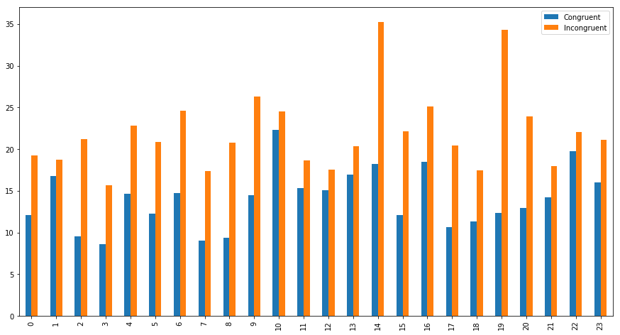

```python
# 在这里创建可视化图表
df.plot(kind='bar',figsize=(15,8))
```

--答案写这里--

可以看出不一致文字条件下说出墨色的时间都比一致文字条件下说出墨色的时间长。

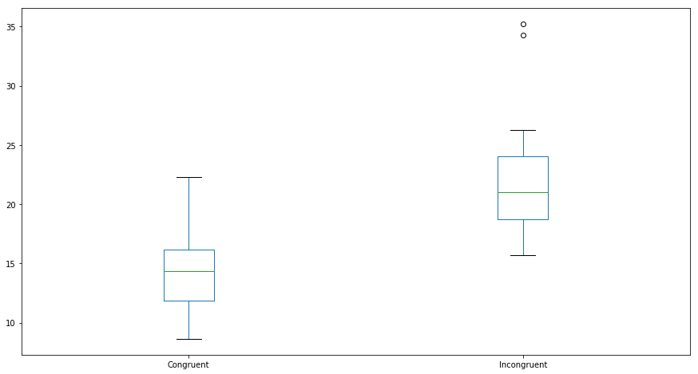

```python
df.plot(kind='box',figsize=(15,8))
```

上图可以看出不一致文字条件和一致文字条件下，说出墨色的时间分布图。并且可以发现，不一致文字条件下有两个异常点，猜想可能对于不一致文字条件下说出墨色的时间相对不同个体有一定差异，即某些个体可能在说出不一致文字条件下的墨色有较大困难，所花费时间明显较长。

(5) 现在，执行统计测试并报告你的结果。你的置信水平和关键统计值是多少？你是否成功拒绝零假设？对试验任务得出一个结论。结果是否与你的期望一致？

```python
# 在这里执行统计检验
```

```python
from scipy.stats import ttest_rel
ttest_rel(df['Congruent'],df['Incongruent'])
```

```
Ttest_relResult(statistic=-8.020706944109957, pvalue=4.1030005857111781e-08)
```

--答案写这里--

结论：假设显著性水平是0.05，关键统计值为p=4.1030005857111781e-08。在 0.05 的显著性水平下，p值小于0.05，可以看出不一致文字条件和一致文字条件下，说出墨色的时间差异非常显著。与期望一致，成功拒绝零假设。

1.差异均值: 7.9648

2.差异标准偏差为: 4.8648

3.标准误差: 0.993

4.t-statistic统计量: 8.0209;8.0209 > 2.069

5.查询[T-table](https://s3.amazonaws.com/udacity-hosted-downloads/t-table.jpg)得到p值是<0.0005的,在α=0.05的情况下,很明显是p < α

参考文献：

[t检验的类型-Minitab](http://support.minitab.com/zh-cn/minitab/17/topic-library/basic-statistics-and-graphs/hypothesis-tests/tests-of-means/types-of-t-tests/)

[什么是临界值-Minitab](https://support.minitab.com/zh-cn/minitab/18/help-and-how-to/statistics/basic-statistics/supporting-topics/basics/what-is-a-critical-value/)

[置信水平或者显著性水平](https://support.minitab.com/zh-cn/minitab/18/help-and-how-to/statistics/basic-statistics/supporting-topics/basics/what-is-a-confidence-level/)

[自由度](https://support.minitab.com/zh-cn/minitab/18/help-and-how-to/statistics/basic-statistics/supporting-topics/tests-of-means/what-are-degrees-of-freedom/)

[关于P值和α值的关系](https://www.zhihu.com/question/21195469/answer/103905842)